[figure not shown]

# Zoekmodi

Meer

Alle instellingen bekijken

Privacy

Zoeken gebruiken

Weergave

Licht thema

[figure not shown]

Donker thema

[figure not shown]

Apparaatstandaard

[figure not shown]

Support

[Help voor Zoeken](https://support.google.com/websearch/?source=g&hl=nl&sa=X&ved=2ahUKEwiDmPWo4Mr2AhUOzyoKHX7EBwwQ8psIegQIARAU)

Tools

[Collecties](https://www.google.com/save?&bih=919&biw=1853&hl=nl&sa=X&ved=2ahUKEwiDmPWo4Mr2AhUOzyoKHX7EBwwQ7XV6BAgBEBY)

[SafeSearch](https://www.google.com/preferences)

# Zoekresultaten

## Afbeeldingen

### Madonna (zangeres) - Wikipedia

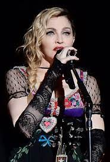

Madonna (zangeres) - Wikipedia

nl.wikipedia.org

### Madonna tijdens de VMA's 2021: Twitter gaat los over haar kont

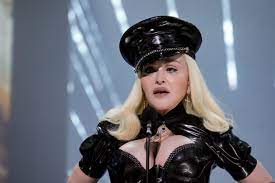

Madonna tijdens de VMA's 2021: Twitter gaat los over haar kont

nsmbl.nl

### Madonna choqueert met foto's waarop tepel te zien is: «Heb een beetje zelfrespect!» - Metrotime

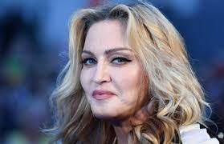

Madonna choqueert met foto's waarop tepel te zien is: «Heb een beetje zelfrespect!» - Metrotime

nl.metrotime.be

### Madonna beschuldigd van fotoshoppen gezicht op fans lichaam | RTL Boulevard

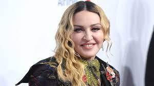

Madonna beschuldigd van fotoshoppen gezicht op fans lichaam | RTL Boulevard

rtlboulevard.nl

### Madonna schokt volgers met sexy foto's en Billie Eilish riskeert weer een wond | Show | AD.nl

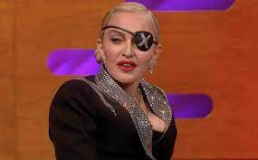

Madonna schokt volgers met sexy foto's en Billie Eilish riskeert weer een wond | Show | AD.nl

ad.nl

### Ophef over foto van Madonna op het toilet: «Moeten we dit sexy vinden?» - Metrotime

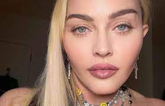

Ophef over foto van Madonna op het toilet: «Moeten we dit sexy vinden?» - Metrotime

nl.metrotime.be

### Madonna beschuldigt rapper Tory Lanez van illegaal gebruik Into the Groove | NU - Het laatste nieuws het eerst op NU.nl

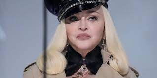

Madonna beschuldigt rapper Tory Lanez van illegaal gebruik Into the Groove | NU - Het laatste nieuws het eerst op NU.nl

nu.nl

### Madonna: 'Wat de MeToo-beweging zegt, vertel ik al mijn hele leven' | Het Parool

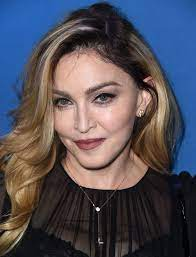

Madonna: 'Wat de MeToo-beweging zegt, vertel ik al mijn hele leven' | Het Parool

parool.nl

### Madonna en haar dochter zijn net zusjes en fans kunnen naar bed met Paris Hilton | Show | AD.nl

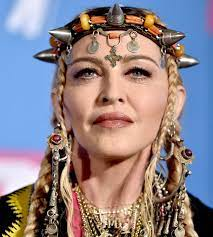

Madonna en haar dochter zijn net zusjes en fans kunnen naar bed met Paris Hilton | Show | AD.nl

ad.nl

### Madonna poseert met 36 jaar jongere vriend én joint op verjaardagstrip | Showbizz 24

[figure not shown]

Madonna poseert met 36 jaar jongere vriend én joint op verjaardagstrip | Showbizz 24

showbizz24.be

### Madonna: 'Geef Britney Spears haar leven terug' | RTL Boulevard

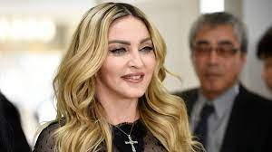

Madonna: 'Geef Britney Spears haar leven terug' | RTL Boulevard

rtlboulevard.nl

### Madonna 'choqueert' tijdens talkshow door meer van zichzelf te tonen dan verwacht | Het Nieuwsblad Mobile

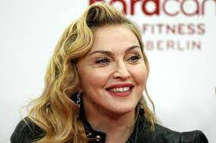

Madonna 'choqueert' tijdens talkshow door meer van zichzelf te tonen dan verwacht | Het Nieuwsblad Mobile

nieuwsblad.be

### Zo viert Madonna haar 63e verjaardag | Sterren | Telegraaf.nl

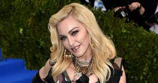

Zo viert Madonna haar 63e verjaardag | Sterren | Telegraaf.nl

telegraaf.nl

### Het Madonna-contrast: zangeres ziet er in het echt helemaal anders uit dan op Instagram | Het Nieuwsblad Mobile

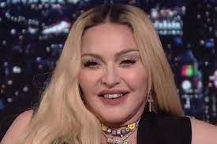

Het Madonna-contrast: zangeres ziet er in het echt helemaal anders uit dan op Instagram | Het Nieuwsblad Mobile

nieuwsblad.be

### Madonna (@Madonna) / Twitter

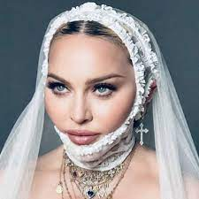

Madonna (@Madonna) / Twitter

twitter.com

### Madonna is jarig

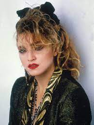

Madonna is jarig

elle.com

### Madonna geeft optreden, wordt amper herkend | Nouveau

[figure not shown]

Madonna geeft optreden, wordt amper herkend | Nouveau

nouveau.nl

### Madonna: 'Ik heb een rol in The Matrix afgeslagen' | Superguide

[figure not shown]

Madonna: 'Ik heb een rol in The Matrix afgeslagen' | Superguide

superguide.nl

### Madonna brengt woensdag nieuwe single uit met zanger Maluma | NU - Het laatste nieuws het eerst op NU.nl

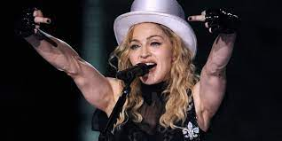

Madonna brengt woensdag nieuwe single uit met zanger Maluma | NU - Het laatste nieuws het eerst op NU.nl

nu.nl

### Madonna 60 jaar: hoe de zangeres een icoon van 'body positivity' werd - EenVandaag

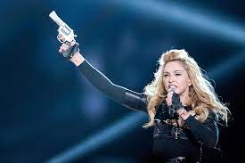

Madonna 60 jaar: hoe de zangeres een icoon van 'body positivity' werd - EenVandaag

eenvandaag.avrotros.nl

### Madonna (63) lijkt meer op Ava Max (27) dan op zichzelf | De Standaard Mobile

[figure not shown]

Madonna (63) lijkt meer op Ava Max (27) dan op zichzelf | De Standaard Mobile

m.standaard.be

### Madonna viert op bijzondere manier 62e verjaardag - Qmusic

[figure not shown]

Madonna viert op bijzondere manier 62e verjaardag - Qmusic

qmusic.nl

### Madonna Is Considering Julia Fox for a Role in Her Biopic

[figure not shown]

Madonna Is Considering Julia Fox for a Role in Her Biopic

harpersbazaar.com

### Madonna, Madonna | CD (album) | Muziek | bol.com

[figure not shown]

Madonna, Madonna | CD (album) | Muziek | bol.com

bol.com

## Gerelateerde zoekopdrachten

madonna **80s**

madonna **2021**

madonna **2022**

## Afbeeldingen

### 116.202 foto's en beelden met Madonna - Getty Images

[figure not shown]

Licentieerbaar

116.202 foto's en beelden met Madonna - Getty Images

gettyimages.nl

### 7 dingen die je nog niet wist over Madonna! - Soundz

[figure not shown]

7 dingen die je nog niet wist over Madonna! - Soundz

soundz.nl

### Madonna albums discography - Wikipedia

[figure not shown]

Madonna albums discography - Wikipedia

en.wikipedia.org

### Madonna geeft optreden, wordt amper herkend | Nouveau

[figure not shown]

Madonna geeft optreden, wordt amper herkend | Nouveau

nouveau.nl

### 116.202 foto's en beelden met Madonna - Getty Images

[figure not shown]

Licentieerbaar

116.202 foto's en beelden met Madonna - Getty Images

gettyimages.nl

### Madonna Is Ready to Destroy the Madonna Biopic | Vanity Fair

[figure not shown]

Madonna Is Ready to Destroy the Madonna Biopic | Vanity Fair

vanityfair.com

### Madonna | Top 40-artiesten

[figure not shown]

Madonna | Top 40-artiesten

top40.nl

### Madonna blijft provoceren met nieuwe kiekjes op social media | RTL Boulevard

[figure not shown]

Madonna blijft provoceren met nieuwe kiekjes op social media | RTL Boulevard

rtlboulevard.nl

### Madonna bevestigt film over haar leven en carrière | Show | AD.nl

[figure not shown]

Madonna bevestigt film over haar leven en carrière | Show | AD.nl

ad.nl

### Madonna regisseert biografiefilm over haar leven | NU - Het laatste nieuws het eerst op NU.nl

[figure not shown]

Madonna regisseert biografiefilm over haar leven | NU - Het laatste nieuws het eerst op NU.nl

nu.nl

### Madonna performs on stage at Wembley - Photographic print for sale

[figure not shown]

Product

Madonna performs on stage at Wembley - Photographic print for sale

artphotolimited.com · Op voorraad

### Madonna | Facebook

[figure not shown]

0:27

Madonna | Facebook

nl-be.facebook.com

### Madonna (60) blijft strijden, maar is niet echt meer aan het winnen | Trouw

[figure not shown]

Madonna (60) blijft strijden, maar is niet echt meer aan het winnen | Trouw

trouw.nl

### Madonna foto - Madonna poster - Kopen - Aankoop / Verkoop

[figure not shown]

Madonna foto - Madonna poster - Kopen - Aankoop / Verkoop

artphotolimited.com

### Madonna

[figure not shown]

Madonna

madonna.com

### V133: MADONNA FOREVER - Madonnaunderground

[figure not shown]

V133: MADONNA FOREVER - Madonnaunderground

madonnaunderground.com

### Madonna - Ray Of Light: Amazon.nl: Muziek

[figure not shown]

Madonna - Ray Of Light: Amazon.nl: Muziek

amazon.nl

### Madonna | Facebook

[figure not shown]

Madonna | Facebook

nl-nl.facebook.com

### Madonna boos over verwijderde tepel-foto's op Instagram | Show | tubantia.nl

[figure not shown]

Madonna boos over verwijderde tepel-foto's op Instagram | Show | tubantia.nl

tubantia.nl

### Madonna: albums, nummers, afspeellijsten | Luister op Deezer

[figure not shown]

Madonna: albums, nummers, afspeellijsten | Luister op Deezer

deezer.com

### Madonna maakt haar opwachting in nieuwe videoclip Snoop Dogg | RTL Boulevard

[figure not shown]

Madonna maakt haar opwachting in nieuwe videoclip Snoop Dogg | RTL Boulevard

rtlboulevard.nl

### Madonna claps back at haters who trolled her for looking 'like a teenager'

[figure not shown]

Madonna claps back at haters who trolled her for looking 'like a teenager'

thenews.com.pk

### Idris Elba en Madonna zoenend gezien op feest in Londen' | NU - Het laatste nieuws het eerst op NU.nl

[figure not shown]

Idris Elba en Madonna zoenend gezien op feest in Londen' | NU - Het laatste nieuws het eerst op NU.nl

nu.nl

### Madonna klaagt verwijderde pikante Instagram-foto's aan met… pikante foto | Het Belang van Limburg Mobile

[figure not shown]

Madonna klaagt verwijderde pikante Instagram-foto's aan met… pikante foto | Het Belang van Limburg Mobile

hbvl.be

## Gerelateerde zoekopdrachten

madonna **now**

madonna **1980**

madonna **2021 age**

[figure not shown]

266 × 390

[figure not shown]

Wikipedia

Madonna (zangeres) - Wikipedia

Bezoeken

Afbeeldingen kunnen auteursrechtelijk beschermd zijn. [Meer informatie](https://support.google.com/legal/answer/3463239?hl=nl)

## Gerelateerde afbeeldingen

[Meer tonen](https://www.google.com/search?q=madonna&tbm=isch&tbs=rimg:CQxQ8J9brDG7YX9_1fpy7W2ahsgIMCgIIABAAOgQIABAA&bih=919&biw=1853&hl=nl&sa=X&ved=0CAIQrnZqFwoTCMihyqrgyvYCFQAAAAAdAAAAABAG)

### Madonna gooit bijzondere foto online en haalt uit naar haters - FHM

[figure not shown]

Madonna gooit bijzondere foto online en haalt uit naar haters - FHM

fhm.nl

### 7 ideeën over Jaren 80 | jaren 80, jaren 80 make-up, make up

[figure not shown]

7 ideeën over Jaren 80 | jaren 80, jaren 80 make-up, make up

pinterest.de

### Retro Radio - Vandaag jarig (1958) Madonna, volledige naam Madonna Louise Veronica Ciccone (Bay City (Michigan) is een Amerikaanse zangeres, actrice en regisseuze. Madonna wordt ook wel de almaar transformerende Queen of

[figure not shown]

Retro Radio - Vandaag jarig (1958) Madonna, volledige naam Madonna Louise Veronica Ciccone (Bay City (Michigan) is een Amerikaanse zangeres, actrice en regisseuze. Madonna wordt ook wel de almaar transformerende Queen of

facebook.com

### De zangeres Madonna | Grabbits

[figure not shown]

De zangeres Madonna | Grabbits

grabbits.nl

### Lang leve de Queen of Pop: Madonna viert vandaag haar 59e verjaardag - Opzij

[figure not shown]

Lang leve de Queen of Pop: Madonna viert vandaag haar 59e verjaardag - Opzij

opzij.nl

### Vandaag (16 augustus) is Madonna jarig (1958-nu) - Muziekdatum.nl

[figure not shown]

Vandaag (16 augustus) is Madonna jarig (1958-nu) - Muziekdatum.nl

muziekdatum.nl

### Style has no age: Madonna is 60! | Nouveau

[figure not shown]

Style has no age: Madonna is 60! | Nouveau

nouveau.nl

### jaren 80 makeup | jaren 80, jaren 80 make-up, jaren 80 stijl

[figure not shown]

jaren 80 makeup | jaren 80, jaren 80 make-up, jaren 80 stijl

nl.pinterest.com

### Van punk tot boho: 20 x Madonna's meest iconische modemomenten - LINDA.nl

[figure not shown]

Van punk tot boho: 20 x Madonna's meest iconische modemomenten - LINDA.nl

linda.nl

### Madonna cancelt concerten wegens coronavirus | Show | AD.nl

[figure not shown]

Madonna cancelt concerten wegens coronavirus | Show | AD.nl

ad.nl

### kleding jaren 80 > OFF-61%

[figure not shown]

kleding jaren 80 > OFF-61%

easygstprofessionals.com

### Stockholm pictures by Neil - MadonnaTribe

[figure not shown]

Stockholm pictures by Neil - MadonnaTribe

news.madonnatribe.com

[Meer tonen](https://www.google.com/search?q=madonna&tbm=isch&tbs=rimg:CQxQ8J9brDG7YX9_1fpy7W2ahsgIMCgIIABAAOgQIABAA&bih=919&biw=1853&hl=nl&sa=X&ved=0CBsQuIIBahcKEwjIocqq4Mr2AhUAAAAAHQAAAAAQBg)

## Gerelateerde zoekopdrachten

[figure not shown]

madonna 2021

[figure not shown]

madonna 80s

[figure not shown]

madonna jaren 90

[figure not shown]

madonna jaren 80

Google-account

b de boer